# next-steps

DJM

15/04/2022

```r
# Required packages
install.packages("tidyverse")
install.packages("glmnet")
install.packages("lme4")
install.packages("selectiveInference")
install.packages("remotes")
remotes::install_github("dajmcdon/sparsegl")
```

# 1 Should we log transform `acc`? Are there outliers?

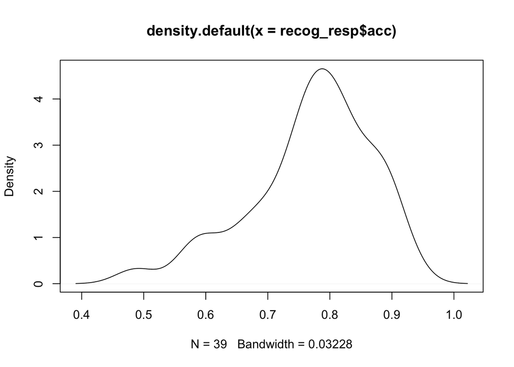

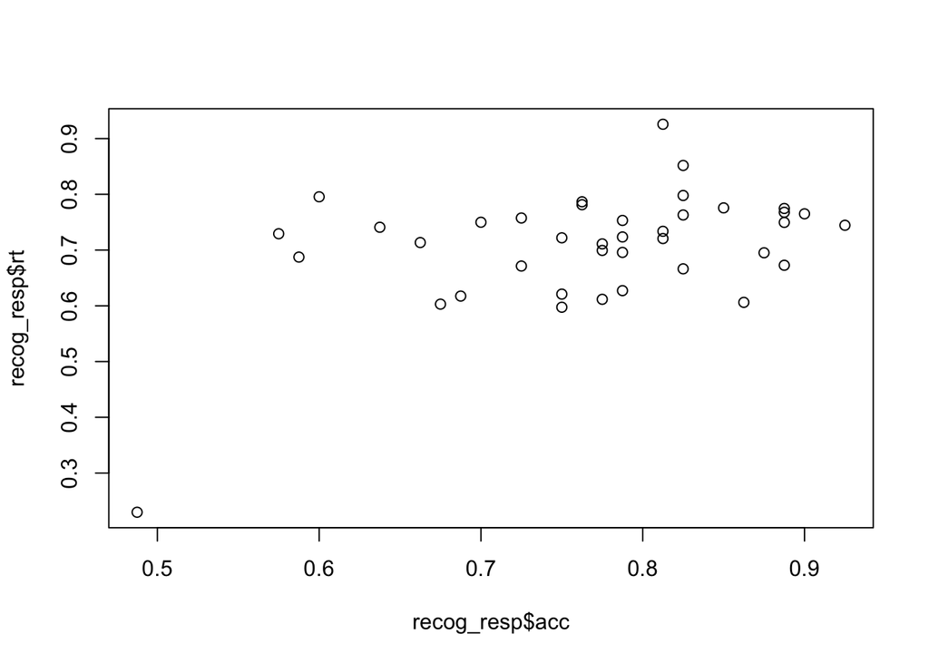

No transformation is needed. Log wouldn’t help. Logit doesn’t do much.

Subject ID 73 should be removed.

# 2 Lasso changes when re-estimated?

Yes. Due to cv. There are too few observations for 10 fold CV. Below we use AIC.

# 3 Tradeoff btw `acc` and `rt`?

See above figure. Seemingly no. `rt` is pretty constant (at least btw subjects). I’d actually drop it from analysis.

# 4 Fit 1: relaxed lasso on means for selected tracks (no grouping)

- for now, we proceed with the mean FA as the predictor
- We also lose the following regions (due to `NA`s):

```
## [1] "leftIFOF"     "rightIFOF"    "rightMDLFang" "rightMDLFspl"
```

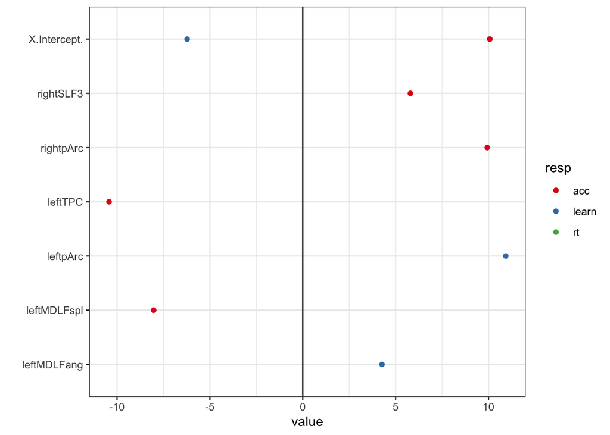

### 4.0.1 Confidence intervals for this fit.

Note that the coefficients are on the scale of the data now, but the design matrix has to be standardized. We invert it

Now we plot them

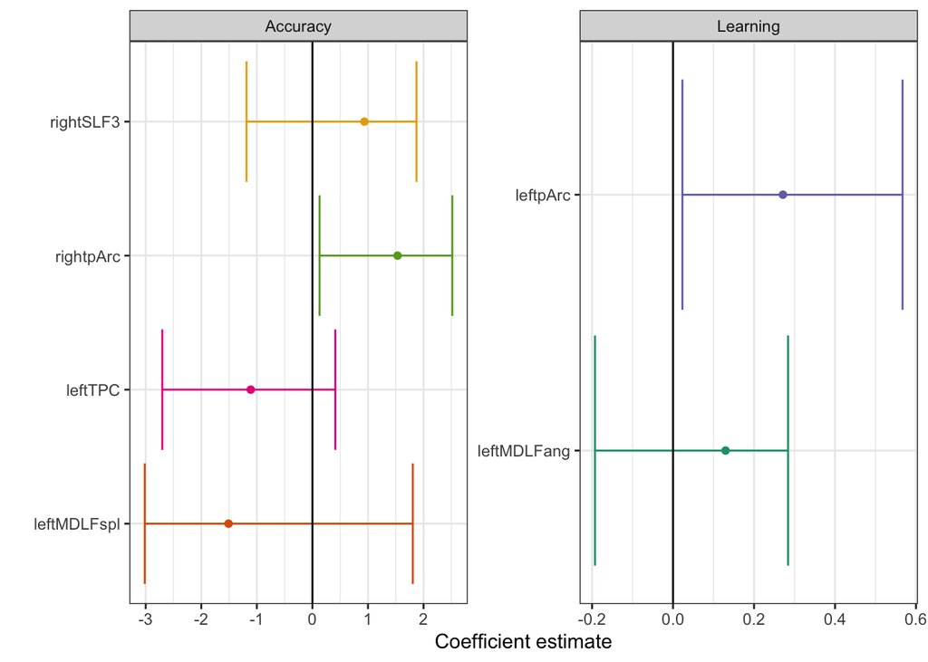

### 4.0.2 Same thing, but just using lm on the selected groups

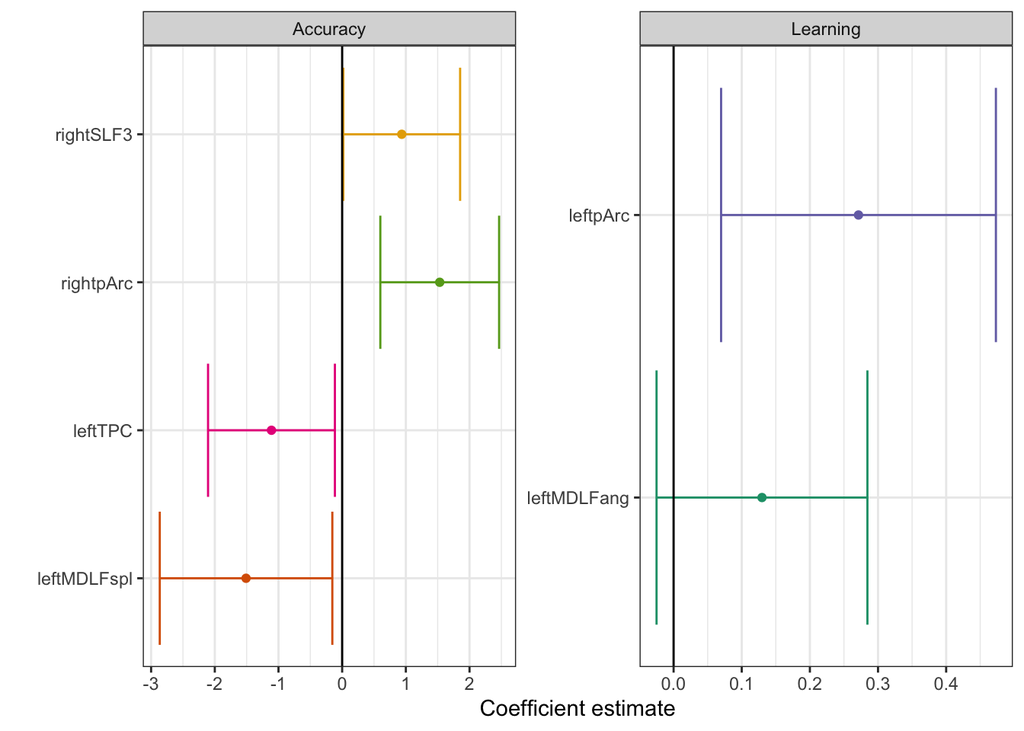

## 4.1 Fit 2: just do lm on everything

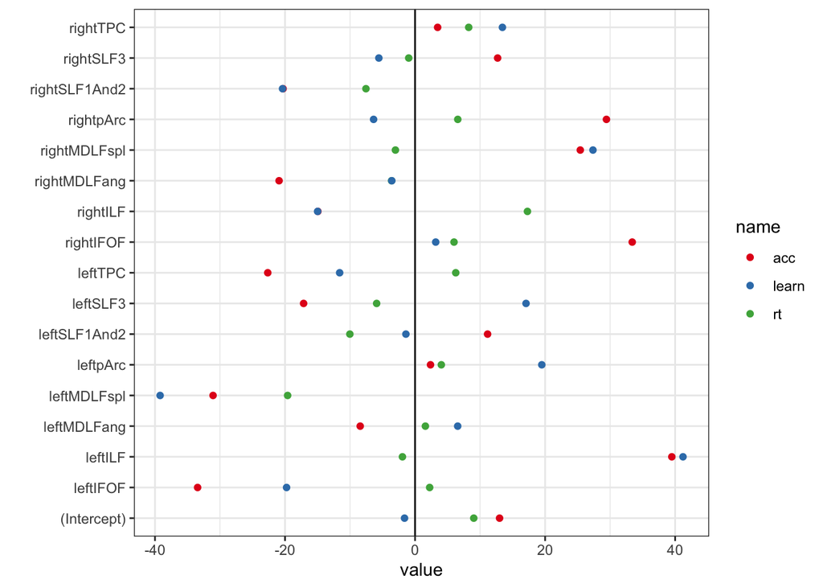

# 5 Group lasso

I wouldn’t bother with group lasso on the mean model. Just lasso (relaxed), or `lm`.

If you want to do group lasso (or sparse gl), I see 4 options

1. For each tract, use all nodes. The groups are PVP/Dorsal/Ventral
2. For each tract, use all nodes. The groups are the tracts.
3. For each tract, use a basis expansion (5-10 df). The groups are PVP/Dorsal/Ventral
4. For each tract, use a basis expansion. The groups are the tracts.

I think 1 and 3 won’t work well. I’d suggest 2 or 4.

## 5.1 Let’s try No. 4

This doesn’t work well for some reason. CV wants the null model while AIC wants the saturated model.

```
## [1] 100
## [1] 100
## [1] 100
```

Here we plot the norms of the groups (always positive).

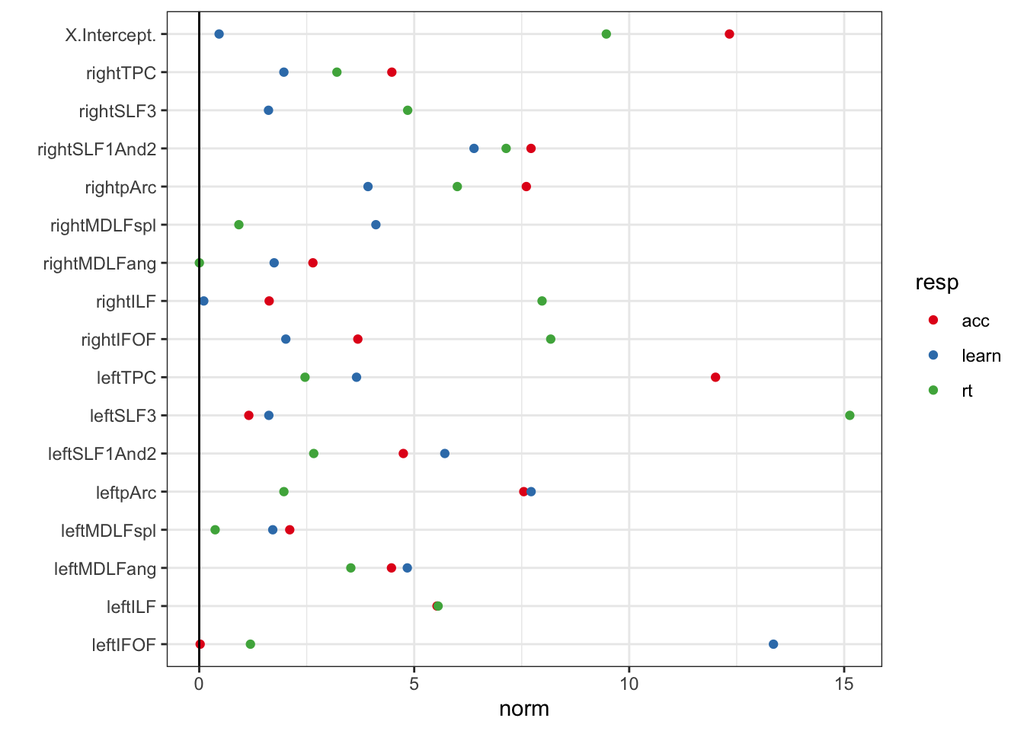